# Relationship between intraclass Correlation (ICC) and Percent Agreement

Jason Bryer

2018-02-23

Inter-rater reliability (IRR) is a critical component of establishing the reliability of measures when more than one rater is necessary. There are numerous IRR statistics available to researchers including percent rater agreement, Cohen’s Kappa, and several types of intraclass correlations (ICC). Several methodologists suggest using ICC over percent rater agreement (Hallgren, 2012; Koo & Li, 2016; McGraw & Wong, 1996; Shrout & Fleiss, 1979). However, the literature provides little guidance on the interpretation of ICC results. This article explores the relationship between ICC and percent rater agreement using simulations. Results suggest that ICC and percent rater agreement are highly correlated ($R^2 > 0.9$) for most designs.

There are several designs for establishing IRR. We are generally concerned with the ratings of **m** subjects by **k** raters. The simplest design is $m x 2$ where two raters score all **m** subjects. However, it common in education to have $m > 2$ raters where each subject is scored by $m = 2$ resulting in a **sparce** matrix. Shrout and Fleiss (1979) provide guidance on which of the six types of ICC to use depending on your design. The six types of ICC considered here are:

- *ICC1* - Each subject is rated by 2 random raters.
- *ICC2* - Each subject is rated by $m > 2$ raters.
- *ICC3* - Each subject is rated by a fixed set of *k* raters.
- *ICC1k* - 2-way ANOVA version of ICC1.
- *ICC2k* - 2-way ANOVA version of ICC2.
- *ICC3k* - 2-way ANOVA version of ICC3.

The `IRRsim` package implements several functions to facilitate simulating various scoring designs. To begin, let’s look at the `simulateRatingMatrix` function. This function will generate an `nEvents` by `k` matrix. For each row, two columns (which represent raters) are randomly selected and each cell of those cells will randomly have a value between 1 and `nLevels`. The likelihood of those two cell having the same value is defined by the `agree` parameter.

```r
test <- simulateRatingMatrix(nLevels = 3, k = 6, agree = 0.6, nEvents = 10)
test
```

```
#>     a  b  c  d  e  f
#> 1  NA NA  1 NA  3 NA
#> 2  NA  1  1 NA NA NA
#> 3  NA  2 NA NA NA  1
#> 4   1 NA NA NA NA  1
#> 5  NA  3 NA NA NA  1
#> 6  NA  1 NA NA NA  1
#> 7   1 NA  2 NA NA NA
#> 8   1  1 NA NA NA NA
#> 9  NA NA NA  3 NA  3
#> 10 NA NA  1 NA  1 NA
```

The `agreement` function will calculate the percent rater agreement for the matrix.

```r
agreement(test)
```

```
#> [1] 0.6
```

For the remainder of the document, we wish to estimate ICC for 6, 9, and 12 raters under the conditions of 3, 5, and 9 scoring levels.

```r
tests.3levels <- simulateICC(nRaters = c(6, 9, 12), nLevels = 3)
tests.5levels <- simulateICC(nRaters = c(6, 9, 12), nLevels = 5)
tests.9levels <- simulateICC(nRaters = c(6, 9, 12), nLevels = 9)
```

The `as.data.frame` function provides the IRR statistics for each of the simulated samples.

```r
test.3levels.df <- as.data.frame(tests.3levels)
dim(test.3levels.df)
```

```
#> [1] 2700   12
```

```r
head(test.3levels.df)
```

```
#>   nLevels nEvents k simAgreement agreement        ICC1        ICC2
#> 1       3     100 6          0.1      0.11 -0.10518190 -0.10458711
#> 2       3     100 6          0.1      0.07 -0.11613871 -0.11223418
#> 3       3     100 6          0.1      0.12 -0.10065224 -0.09693583
#> 4       3     100 6          0.1      0.14 -0.08291602 -0.08061092
#> 5       3     100 6          0.1      0.09 -0.09734845 -0.09884336
#> 6       3     100 6          0.1      0.13 -0.07468918 -0.07586571
#>          ICC3      ICC1k      ICC2k      ICC3k Cohen_Kappa
#> 1 -0.10471161 -1.3311623 -1.3153835 -1.3186700  -0.3261809
#> 2 -0.11318341 -1.6618685 -1.5345496 -1.5644487  -0.3857845
#> 3 -0.09764098 -1.2157565 -1.1286463 -1.1446884  -0.3101087
#> 4 -0.08093780 -0.8498108 -0.8102341 -0.8157531  -0.2934276
#> 5 -0.09856274 -1.1380067 -1.1725580 -1.1659945  -0.3713080
#> 6 -0.07571645 -0.7152377 -0.7333901 -0.7310681  -0.3126132
```

The following three figures show ICC1 against percent rater agreement with 3, 5, and 9 score levels, respectively.

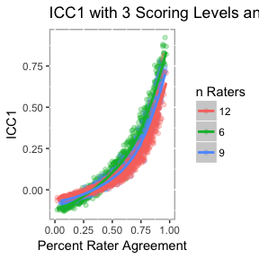

```r
plot(tests.3levels, stat = 'ICC1')
```

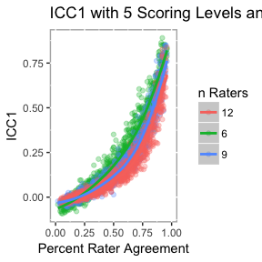

```r
plot(tests.5levels, stat = 'ICC1')
```

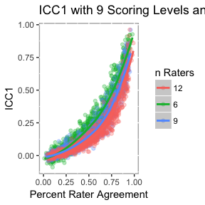

```r
plot(tests.9levels, stat = 'ICC1')
```

The figure below show the relationship between percent rater agreement and intraclass correlation for the six types of ICC.

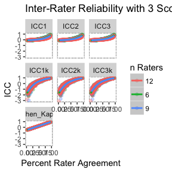

```r
plot(tests.3levels)
```

The literature suggests that ICC be used over percent agreement. However, the figures above suggest there is a strong relationship between percent rater agreement and ICC. Below, we fit a quadratic model predicting ICC1 from percent agreement. In all three cases the resulting $R^2$ is greater than .9!

```r
tests.3levels.sum <- summary(tests.3levels, stat = 'ICC1', method = 'quadratic')
summary(tests.3levels.sum$model[[1]]) # k = 6 raters
```

```
#>
#> Call:
#> lm(formula = as.formula(paste0(stat, " ~ I(agreement^2) + agreement")),
#>     data = test)
#>
#> Residuals:
#>      Min       1Q   Median       3Q      Max
#> -0.15421 -0.02723  0.00141  0.02826  0.17435
#>
#> Coefficients:
#>                 Estimate Std. Error t value Pr(>|t|)
#> (Intercept)    -0.061833   0.005384  -11.48   <2e-16 ***
#> I(agreement^2)  1.148901   0.024137   47.60   <2e-16 ***
#> agreement      -0.259151   0.024748  -10.47   <2e-16 ***
#> ---
#> Signif. codes:  0 '***' 0.001 '**' 0.01 '*' 0.05 '.' 0.1 ' ' 1
#>
#> Residual standard error: 0.04447 on 897 degrees of freedom
#> Multiple R-squared:  0.968,  Adjusted R-squared:  0.9679
#> F-statistic: 1.355e+04 on 2 and 897 DF,  p-value: < 2.2e-16
```

```r
summary(tests.3levels.sum$model[[2]]) # k = 9 raters
```

```
#>
#> Call:
#> lm(formula = as.formula(paste0(stat, " ~ I(agreement^2) + agreement")),
#>     data = test)
#>
#> Residuals:
#>       Min        1Q    Median        3Q       Max
#> -0.174955 -0.024512  0.001965  0.021628  0.213082
#>
#> Coefficients:
#>                 Estimate Std. Error t value Pr(>|t|)
#> (Intercept)    -0.003624   0.005282  -0.686    0.493
#> I(agreement^2)  1.161933   0.023466  49.516   <2e-16 ***
#> agreement      -0.452329   0.024139 -18.738   <2e-16 ***
#> ---
#> Signif. codes:  0 '***' 0.001 '**' 0.01 '*' 0.05 '.' 0.1 ' ' 1
#>
#> Residual standard error: 0.043 on 897 degrees of freedom
#> Multiple R-squared:  0.9556, Adjusted R-squared:  0.9555
#> F-statistic:  9645 on 2 and 897 DF,  p-value: < 2.2e-16
```

```r
summary(tests.3levels.sum$model[[3]]) # k = 12 raters
```

```
#>
#> Call:
#> lm(formula = as.formula(paste0(stat, " ~ I(agreement^2) + agreement")),
#>     data = test)
#>
#> Residuals:
#>       Min        1Q    Median        3Q       Max
#> -0.118674 -0.026590  0.002324  0.023175  0.284906
#>
#> Coefficients:
#>                 Estimate Std. Error t value Pr(>|t|)
#> (Intercept)     0.014334   0.005248   2.731  0.00643 **
#> I(agreement^2)  1.072899   0.023747  45.180  < 2e-16 ***
#> agreement      -0.477595   0.024264 -19.683  < 2e-16 ***
#> ---
#> Signif. codes:  0 '***' 0.001 '**' 0.01 '*' 0.05 '.' 0.1 ' ' 1
#>
#> Residual standard error: 0.04342 on 897 degrees of freedom
#> Multiple R-squared:  0.9381, Adjusted R-squared:  0.9379
#> F-statistic:  6793 on 2 and 897 DF,  p-value: < 2.2e-16
```